# Practical Machine Learning - Course Project

Akshaya Srivastava

Sunday, October 26, 2014

# Predictive Analytics - Predicting Exercise Qualilty

### I. Synopsis

Using devices such as Jawbone Up, Nike FuelBand, and Fitbit it is now possible to collect a large amount of data about personal activity relatively inexpensively. These type of devices are part of the quantified self movement - a group of enthusiasts who take measurements about themselves regularly to improve their health, to find patterns in their behavior, or because they are tech geeks. Some of the applications of this data range as far as elderly monitoring, life log systems for monitoring energy expenditure, and for supporting weight-loss programs.

By using data from accelerometers on the belt, forearm, arm, and dumbell of 6 participants, we can attempt to quantify how well dumbbell lifts were performed. With enough data, we will be able to predict the manner in which they did the exercise: exactly according to the specification (Class A), throwing the elbows to the front (Class B), lifting the dumbbell only halfway (Class C), lowering the dumbbell only halfway (Class D) and throwing the hips to the front (Class E)

The *Weight Lifting Exercises Dataset* is harvested from the following paper:

Velloso, E.; Bulling, A.; Gellersen, H.; Ugulino, W.; Fuks, H. [Qualitative Activity Recognition of Weight Lifting Exercises](http://groupware.les.inf.puc-rio.br/work.jsf?p1=11201). Proceedings of 4th International Conference in Cooperation with SIGCHI (Augmented Human ’13) . Stuttgart, Germany: ACM SIGCHI, 2013.

### II. General Housekeeping

```r
library(AppliedPredictiveModeling)
library(caret)
library(rattle)
```

```r
library(rpart.plot)
library(randomForest)
```

### III. Downloading and preprocessing data files

```r
# Download Data Files
    download.file("http://d396qusza40orc.cloudfront.net/predmachlearn/pml-training.csv", destfile = "./pml-training.csv")
    download.file("http://d396qusza40orc.cloudfront.net/predmachlearn/pml-testing.csv", destfile = "./pml-testing.csv")

# Import data while substituting empty values as 'NA'.
        training <- read.csv("./pml-training.csv", na.strings=c("NA",""), header=TRUE)
        colnames_train <- colnames(training)

        testing <- read.csv("./pml-testing.csv", na.strings=c("NA",""), header=TRUE)
        colnames_test <- colnames(testing)

# Verify that the column names (excluding classe and problem_id) are identical in both the training and the test set.
        all.equal(colnames_train[1:length(colnames_train)-1], colnames_test[1:length(colnames_train)-1])
```

```
## [1] TRUE
```

```r
# Count the number of non-NAs in each column
        nonNAs <- function(x) {
                as.vector(apply(x, 2, function(x) length(which(!is.na(x)))))
                }

# Build vector of missing data or NA columns to drop.
        colcnts <- nonNAs(training)
        drops <- c()
        for (cnt in 1:length(colcnts)) {
                if (colcnts[cnt] < nrow(training)) {
                        drops <- c(drops, colnames_train[cnt])
                        }
                }

# Drop NA data and the first 7 columns as they are unnecessary for prediction.
        training <- training[,!(names(training) %in% drops)]
        training <- training[,8:length(colnames(training))]

        testing <- testing[,!(names(testing) %in% drops)]
        testing <- testing[,8:length(colnames(testing))]

# Remove near zero covariates
        nsv <- nearZeroVar(training,saveMetrics=TRUE)
        head(nsv)
```

```
##                  freqRatio percentUnique zeroVar   nzv
## roll_belt         1.101904     6.7781062   FALSE FALSE
## pitch_belt        1.036082     9.3772296   FALSE FALSE
## yaw_belt          1.058480     9.9734991   FALSE FALSE
## total_accel_belt  1.063160     0.1477933   FALSE FALSE
## gyros_belt_x      1.058651     0.7134849   FALSE FALSE
## gyros_belt_y      1.144000     0.3516461   FALSE FALSE
```

```r
        training <- training[,!nsv$nzv]
        testing <- testing[,!nsv$nzv]
```

Given that all of the near zero variance variables (nsv) are FALSE, there’s no need to eliminate any covariates due to lack of variablility.

### IV. Split data to training and testing for cross validation.

```r
        inTrain <- createDataPartition(y=training$classe, p=0.7, list=FALSE)
        new_training <- training[inTrain,]
        new_testing <- training[-inTrain,]
```

We got 13737 samples and 53 variables for training; 5885 samples and 53 variables for testing.

### V. Analysis

Now we fit a tree to these data, and summarize/plot it. First, we use the ‘tree’ package because it is much faster than ‘caret’ package.

```r
#install.packages("tree")
library(tree)
set.seed(1990)
        tree.training=tree(classe~.,data=new_training)
        summary(tree.training)
```

```
##
## Classification tree:
## tree(formula = classe ~ ., data = new_training)
## Variables actually used in tree construction:
##  [1] "roll_belt"         "pitch_forearm"     "roll_forearm"
##  [4] "magnet_dumbbell_x" "magnet_dumbbell_y" "magnet_dumbbell_z"
##  [7] "pitch_belt"        "yaw_belt"          "accel_forearm_z"
## [10] "accel_forearm_x"
## Number of terminal nodes:  17
## Residual mean deviance:  1.734 = 23790 / 13720
## Misclassification error rate: 0.3357 = 4611 / 13737
```

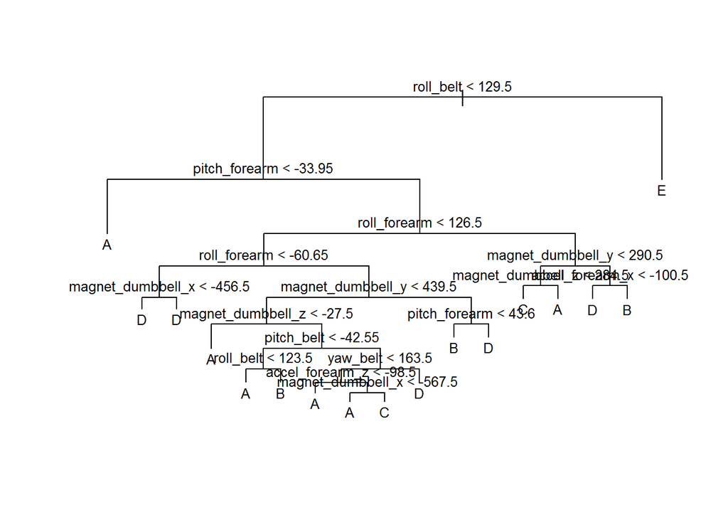

```r
        plot(tree.training)
        text(tree.training, pretty=0, cex =.8)
```

#### 2. Use Rpart form Caret (very slow processing)

```r
library(caret)
set.seed(32323)

        modFit <- train(classe ~ .,method="rpart",data=new_training)
        print(modFit$finalModel)
```

```
## n= 13737
##
## node), split, n, loss, yval, (yprob)
##       * denotes terminal node
##
##  1) root 13737 9831 A (0.28 0.19 0.17 0.16 0.18)
##    2) roll_belt< 130.5 12607 8712 A (0.31 0.21 0.19 0.18 0.11)
##      4) pitch_forearm< -33.95 1097    5 A (1 0.0046 0 0 0) *
##      5) pitch_forearm>=-33.95 11510 8707 A (0.24 0.23 0.21 0.2 0.12)
##       10) magnet_dumbbell_y< 439.5 9749 7000 A (0.28 0.18 0.24 0.19 0.11)
##         20) roll_forearm< 123.5 6043 3589 A (0.41 0.18 0.18 0.17 0.062) *
##         21) roll_forearm>=123.5 3706 2501 C (0.08 0.18 0.33 0.23 0.19) *
##       11) magnet_dumbbell_y>=439.5 1761  850 B (0.031 0.52 0.045 0.22 0.19) *
##    3) roll_belt>=130.5 1130   11 E (0.0097 0 0 0 0.99) *
```

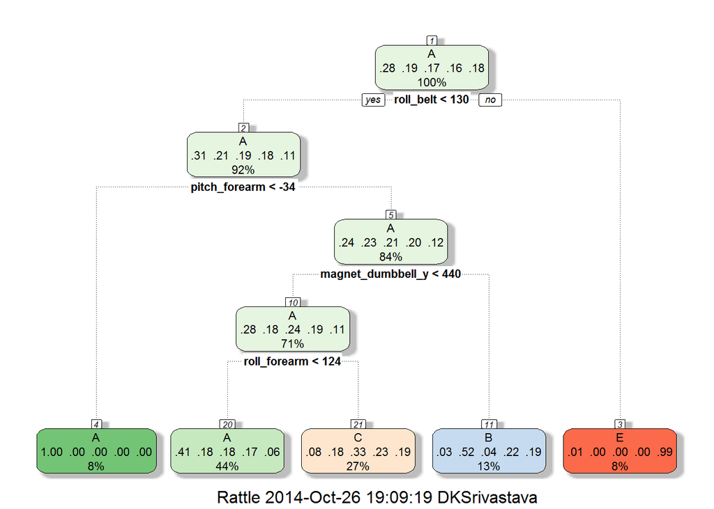

```r
# Draw a Prettier plot

library(rattle)
fancyRpartPlot(modFit$finalModel)
```

#### 3. Cross Validation

Check the performance of the tree on the testing data by cross validation.

```r
        tree.pred=predict(tree.training,new_testing,type="class")
        predMatrix = with(new_testing,table(tree.pred,classe))
        sum(diag(predMatrix))/sum(as.vector(predMatrix)) # error rate for tree
```

```
## [1] 0.6630416
```

```r
        tree.pred=predict(modFit,new_testing)
        predMatrix = with(new_testing,table(tree.pred,classe))
        sum(diag(predMatrix))/sum(as.vector(predMatrix)) # error rate for caret
```

```
## [1] 0.500085
```

#### 4. Pruning the tree

Use Cross Validation to prune the tree.

```r
        cv.training=cv.tree(tree.training,FUN=prune.misclass)
        cv.training
```

```
## $size
##  [1] 17 16 15 14 13 12 11  8  7  6  2  1
##
## $dev
##  [1] 4732 4732 4798 5096 5219 5275 5628 5676 6644 7219 8722 9831
##
## $k
##  [1]    -Inf    0.00   66.00  144.00  173.00  187.00  206.00  224.00
##  [9]  315.00  412.00  481.75 1118.00
##
## $method
## [1] "misclass"
##
## attr(,"class")
## [1] "prune"         "tree.sequence"
```

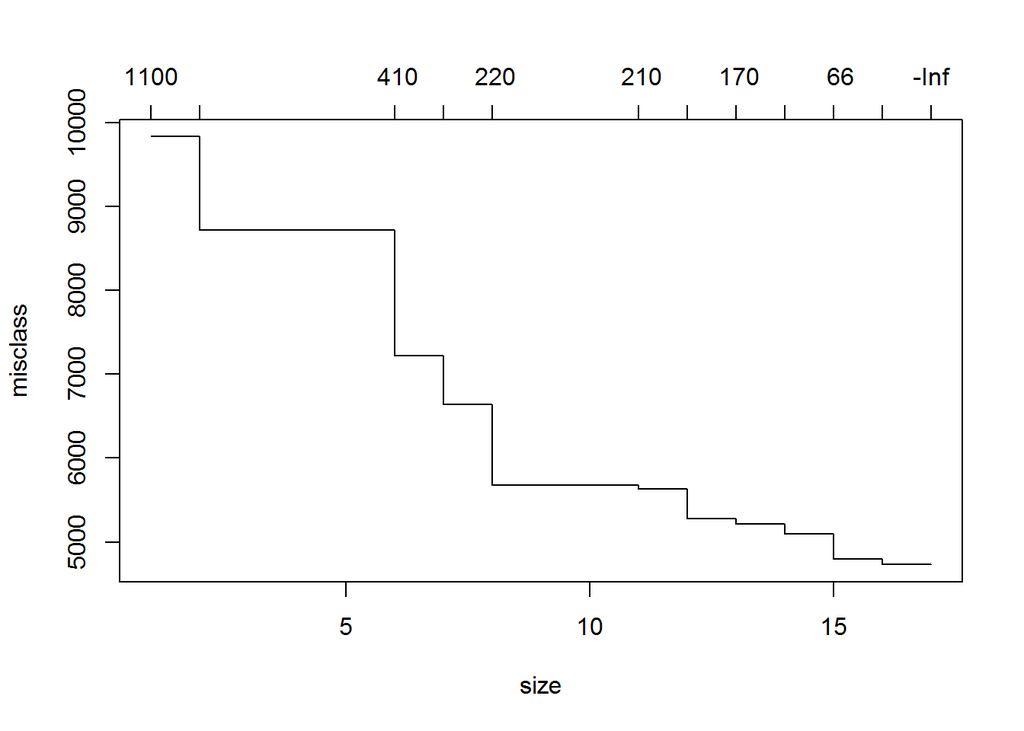

```r
        plot(cv.training)
```

The plot shows that when the size of the tree goes down, the deviance goes up. It means the 16 is a good size (i.e. number of terminal nodes) for this tree. We do not need to prune it.

Suppose we prune it at size of nodes at 12.

```r
        prune.training=prune.misclass(tree.training,best=12)
```

Now lets evaluate this pruned tree on the test data.

```r
        tree.pred=predict(prune.training,new_testing,type="class")
        predMatrix = with(new_testing,table(tree.pred,classe))
        sum(diag(predMatrix))/sum(as.vector(predMatrix)) # error rate
```

```
## [1] 0.6205607
```

The single tree is not good enough, so we should use random forests.

### VI. Random Forests

These methods use trees as building blocks to build more complex models.

#### 1. Random Forests

Random forests build lots of bushy trees and then average them to reduce the variance.

```r
library(randomForest)
set.seed(1990)

#Lets fit a random forest and see how well it performs.

        rf.training=randomForest(classe~.,data=new_training,ntree=100, importance=TRUE)
        rf.training
```

```
##
## Call:
##  randomForest(formula = classe ~ ., data = new_training, ntree = 100,      importance = TRUE)
##                Type of random forest: classification
##                      Number of trees: 100
## No. of variables tried at each split: 7
##
##         OOB estimate of  error rate: 0.69%
## Confusion matrix:
##      A    B    C    D    E class.error
## A 3900    5    0    0    1 0.001536098
## B   16 2634    8    0    0 0.009029345
## C    0   23 2370    3    0 0.010851419
## D    1    0   27 2223    1 0.012877442
## E    0    0    3    7 2515 0.003960396
```

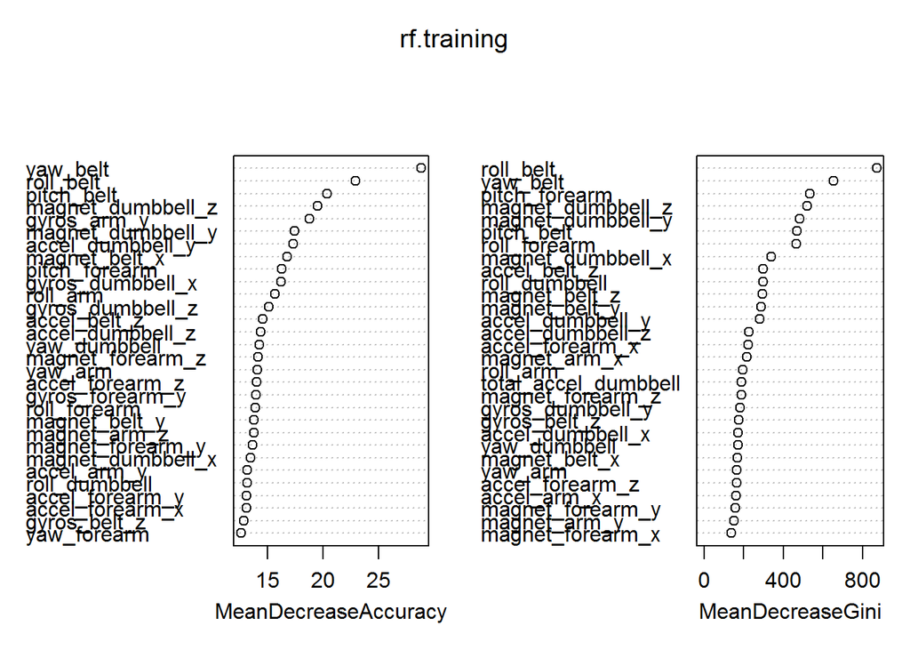

```r
        #plot(rf.training, log="y")
        varImpPlot(rf.training,)
```

```r
        #rf.training1=randomForest(classe~., data=new_training, proximity=TRUE )
        #DSplot(rf.training1, new_training$classe)
```

we can see which variables have higher impact on the prediction.

### VII. Out-of Sample Accuracy

Lets evaluate this tree on the test data.

```r
        tree.pred=predict(rf.training,new_testing,type="class")
        predMatrix = with(new_testing,table(tree.pred,classe))
        sum(diag(predMatrix))/sum(as.vector(predMatrix)) # error rate
```

```
## [1] 0.9957519
```

### VIII. Conclusion

Now we can predict the testing data from the website.

```r
        answers <- predict(rf.training, testing)
        print(answers)
```

```
##  1  2  3  4  5  6  7  8  9 10 11 12 13 14 15 16 17 18 19 20
##  B  A  B  A  A  E  D  B  A  A  B  C  B  A  E  E  A  B  B  B
## Levels: A B C D E
```

It shows that this random forest model performed a better job.

.